# hw1-2

강현승

2022-10-29

# HW 1-2

본 문서에서 사용한 데이터

1. 서울시 지하철역 엘리베이터 위치정보 ~ 서울특별시 서울 열린데이터 광장
   - https://data.seoul.go.kr/dataList/OA-21212/S/1/datasetView.do
2. 국토교통부_전국 법정동 ~ 공공데이터포탈
   - https://www.data.go.kr/data/15063424/fileData.do
3. 서울특별시_ 장애유형별, 등급별 장애인등록현황 ~ 공공데이터포탈
   - https://www.data.go.kr/data/15047058/fileData.do

이 문서의 환경변수

```r
# 해당 API 접근을 위한 인증키 설정 부분
seoul_metro_api_key = '6e505a58676b68733130386b59574e6c'

# 전국 법정동 정보와 서울 시 장애인 등록 현황을 불러오기 위한 url 정보 등록
address_system_url = 'https://o365pknu-my.sharepoint.com/:x:/g/personal/khskeb0513_office_pknu_ac_kr/EZRYyrzarnJOmCNEOkZhr44BwpfzeHs_Oe-ej0VCuHo0sQ?e=CcLUbS&download=1'
registered_disbaled_url = 'https://o365pknu-my.sharepoint.com/:x:/g/personal/khskeb0513_office_pknu_ac_kr/EdvnKIClFdVEgAnqRiPcfmcBNFHkRtTvgN7TTPXsV6io8Q?e=N6Aogj&download=1'
```

아래 코드를 통해서 서울시 지하철 역 엘리베이터 위치 정보를 데이터프레임화하고자 한다.

```r
# jsonlite 패키지 사용을 하겠다는 선언
library(jsonlite)

# 상기한 API 인증키를 통해 API에 접근하기 위한 URL을 생성
seoul_metro_ev_api_url = paste0(
  'http://openapi.seoul.go.kr:8088/',
  seoul_metro_api_key,
  '/json/tbTraficElvtr/1/1000'
)

# fromJSON 메소드를 사용하여 위에서 생성한 URL로 HTTP 요청하여 json 응답을 해석 후 메모리에 저장
seoul_metro_ev_parsed = fromJSON(seoul_metro_ev_api_url)
# 위의 seoul_metro_ev_parsed 는 fromJSON의 산출물로써 list 타입을 가지고 있는데, nested하므로 하위의 tbTraficElvtr > row 내의 list들을 데이터프레임화하는 과정이다.
seoul_metro_ev_df = data.frame(seoul_metro_ev_parsed$tbTraficElvtr$row)

# seoul_metro_ev_df 출력
str(seoul_metro_ev_df)
```

```
## 'data.frame':    643 obs. of  10 variables:
##  $ TYPE     : chr  "NODE" "NODE" "NODE" "NODE" ...
##  $ NODE_WKT : chr  "POINT(126.98404302021133 37.570384160886874)" "POINT(126.97413365201709 37.575965675947124)" "POINT(127.01546995294608 37.579924238231975)" "POINT(127.01219046837087 37.57213417569109)" ...
##  $ NODE_ID  : num  212643 212372 167346 160421 160668 ...
##  $ NODE_CODE: chr  "1" "1" "1" "1" ...
##  $ SGG_CD   : chr  "1111000000" "1111000000" "1111000000" "1111000000" ...
##  $ SGG_NM   : chr  "종로구" "종로구" "종로구" "종로구" ...
##  $ EMD_CD   : chr  "1111013800" "1111010700" "1111017500" "1111017400" ...
##  $ EMD_NM   : chr  "종로2가" "적선동" "숭인동" "창신동" ...
##  $ SW_CD    : chr  "273" "271" "" "" ...
##  $ SW_NM    : chr  "종각" "경복궁(정부서울청사)" "" "" ...
```

아래 코드를 통해서 `국토교통부_전국 법정동_20211217.csv`을 데이터프레임화, 서울 시의 법정동만 추출하고자 한다.

```r
# read.csv 메소드를 사용하여 address_system_url로 HTTP 요청하여 csv 응답을 해석 후 메모리에 저장
address_system_df = read.csv(address_system_url, fileEncoding = 'euc-kr')
# subset 메소드를 사용하여 address_system_df의 행 중 시도명이 '서울특별시'이며, 삭제일자가 비어있고, 읍면동이 비어있지 않은 행을 선택하여 address_system_seoul_df 변수에 저장
address_system_seoul_df = subset(address_system_df,
                                 시도명 == '서울특별시' &
                                   삭제일자 == '' &
                                   읍면동명 != '',
                                 c('시도명', '시군구명', '읍면동명'))

# seoul_metro_ev_df 출력
str(address_system_seoul_df)
```

```
## 'data.frame':    467 obs. of  3 variables:
##  $ 시도명  : chr  "서울특별시" "서울특별시" "서울특별시" "서울특별시" ...
##  $ 시군구명: chr  "용산구" "용산구" "용산구" "용산구" ...
##  $ 읍면동명: chr  "용산동3가" "용산동5가" "한강로3가" "이촌동" ...
```

아래 코드를 통해서 `서울특별시_ 장애유형별, 등급별 장애인등록현황_20180930.csv`을 데이터프레임화, 서울 시의 장애인 등록현황을 데이터프레임화하고자 한다.

```r
# read.csv 메소드를 사용하여 registered_disbaled_url로 HTTP 요청하여 csv 응답을 해석 후 메모리에 저장
registered_disabled_df = read.csv(registered_disbaled_url, fileEncoding = 'euc-kr')

# registered_disabled_df 출력
# str(registered_disabled_df)
```

아래 코드를 통해서 서울 시 행정구 별 장애인등록총원을 구하여 `registered_disabled_df`에 `total_registered_disabled` 열로 추가하고자 한다.

```r
# 계산된 장애인등록총원을 저장할 배열 변수
total_registered_disabled = c()
# row, 즉 행정구의 수 만큼 반복하기 위한 for 구문
for (i in 1:nrow(registered_disabled_df)) {
  # 앞선 total_registered_disabled에 registered_disabled_df의 행정구별 장애등급별 장애인 수를 합하여 배열의 마지막 원소로 추가
  total_registered_disabled = append(total_registered_disabled, sum(registered_disabled_df[i,][2:76]))
}
# registered_disabled_df에 total_registered_disabled 열로 total_registered_disabled 변수의 값을 추가
registered_disabled_df$total_registered_disabled = total_registered_disabled
```

아래 코드를 통해서 서울 시 행정동 별 지하철 역 엘리베이터 수를 구하여 `address_system_df`에 `ev_count_by_emd` 열로 추가하고자 한다.

```r
# seoul_metro_ev_by_emd_df 변수에 seoul_metro_ev_df 데이터프레임의 중복된 행정구와 법정동명을 가지고 있는 행들을 분류하여 그 개수를 저장
seoul_metro_ev_by_emd_df = aggregate(
  seoul_metro_ev_df$TYPE ~ seoul_metro_ev_df$SGG_NM + seoul_metro_ev_df$EMD_NM,
  seoul_metro_ev_df,
  length
)
# seoul_metro_ev_by_emd_df 데이터프레임 변수의 열 이름을 아래와 같이 변경
colnames(seoul_metro_ev_by_emd_df) = c('SGG', 'EMD', 'EV_COUNT')
# 앞선 address_system_seoul_df의 모든 행을 반복하여 address_system_seoul_df의 행 내 행정구 및 법정동 이름과 일치하는 seoul_metro_ev_by_emd_df의 행을 찾는다
# 만약 seoul_metro_ev_by_emd_df 내에 일치하는 행이 있으면 해당 행의 ev_count_by_emd (법정동에 따른 지하철 역 엘리베이터 수) 값을 리턴, 없으면 NA 리턴
# apply 메소드 내 익명함수가 리턴한 값을 모아 ev_count_by_emd에 배열로 저장
ev_count_by_emd = apply(address_system_seoul_df, 1, function(row) {
  selected_ev_data = subset(seoul_metro_ev_by_emd_df, SGG == row[2] &
                              EMD == row[3])
  if (length(selected_ev_data) == 0) {
    return(NA)
  } else {
    return(selected_ev_data[1, 3])
  }
})
# 위의 ev_count_by_emd를 address_system_seoul_df의 ev_count_by_emd라는 새로운 열의 데이터로 설정
address_system_seoul_df$ev_count_by_emd = ev_count_by_emd
```

아래 코드를 통해서 `address_system_seoul_df$ev_count_by_emd`(법정동 별 지하철 역 엘리베이터 수)의 평균을 구하고자 한다.

```r
# 열에 NA를 포함하고 있어 결과가 나오지 않음
mean(address_system_seoul_df$ev_count_by_emd)
```

```
## [1] NA
```

```r
# NA가 포함된 행을 제하고 계산한 평균
# ( 서울 시 내 지하철 역 엘리베이터 수 ) / ( 서울 시 내 지하철이 설치된 법정동 수 )
mean(address_system_seoul_df$ev_count_by_emd, na.rm = T)
```

```
## [1] 3.047393
```

```r
# NA가 포함된 행을 0으로 만들어 계산한 평균
# ( 서울 시 내 지하철 역 엘리베이터 수 ) / ( 서울 시 내 법정동 수 )
mean(replace(
  address_system_seoul_df$ev_count_by_emd,
  is.na(address_system_seoul_df$ev_count_by_emd),
  0
))
```

```
## [1] 1.376874
```

아래 코드를 통해서 서울 시 내 지하철이 설치된 법정동들의 평균보다 적은 지하철 역 엘리베이터 수를 가진 법정동 개수를 구하고자 한다.

```r
# 평균에 미치지 못하는 EV_COUNT를 가진 행의 개수를 nrow 메소드로 세아림
nrow(seoul_metro_ev_by_emd_df[seoul_metro_ev_by_emd_df$EV_COUNT < mean(seoul_metro_ev_by_emd_df$EV_COUNT),])
```

```
## [1] 148
```

아래 코드를 통해서 `seoul_metro_ev_by_emd_df$EV_COUNT`와 `registered_disabled_df$total_registered_disabled`의 min-max normalization을 실시하고 이의 결과를 normalized라는 데이터프레임에 저장하고자 한다.

```r
# 읍면동으로 분류되어 있는 데이터를 상위 행정구로 값들을 더하여 간추림
seoul_metro_ev_by_sgg_df = aggregate(
  seoul_metro_ev_by_emd_df$EV_COUNT ~ seoul_metro_ev_by_emd_df$SGG,
  seoul_metro_ev_by_emd_df,
  sum
)
# seoul_metro_ev_by_sgg_df를 행정구 이름의 가나다 순으로 정렬
seoul_metro_ev_by_sgg_df = seoul_metro_ev_by_sgg_df[order(seoul_metro_ev_by_sgg_df$`seoul_metro_ev_by_emd_df$SGG`), ]
# 행정구 별 장애인 등록 집계표를 행정구 이름의 가나다 순으로 정렬
registered_disabled_df = registered_disabled_df[order(registered_disabled_df$유형.등급.),]

# min-max normalizaion을 위한 함수 생성
normalization = function(vector) {
  return ((vector - min(vector)) / (max(vector) - min(vector)))
}
# normalized 데이터프레임 생성
# normed_로 시작하는 열은 모두 위의 normalization 함수의 산출물 값임
normalized = data.frame(
  SGG = seoul_metro_ev_by_sgg_df$`seoul_metro_ev_by_emd_df$SGG`,
  ev_count = seoul_metro_ev_by_sgg_df$`seoul_metro_ev_by_emd_df$EV_COUNT`,
  normed_ev_count = normalization(
    seoul_metro_ev_by_sgg_df$`seoul_metro_ev_by_emd_df$EV_COUNT`
  ),
  registered_diabled_count = registered_disabled_df$total_registered_disabled,
  normed_registered_diabled_count = normalization(registered_disabled_df$total_registered_disabled)
)
```

아래의 코드를 통하여 normalized를 시각화하고자 한다.

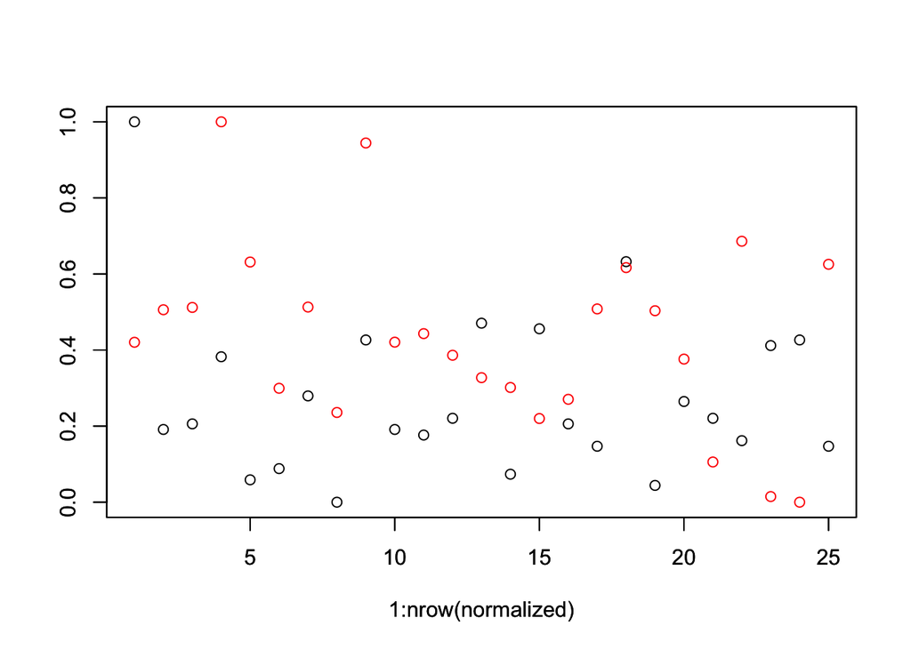

```r
# plot 함수를 사용하여 정규화된 엘리베이터 수를 표시
plot(1:nrow(normalized), normalized$normed_ev_count, ylab = '')
# plot 함수가 그린 그래프가 겹칠 수 있도록 한다
par(new = T)
# plot 함수를 사용하여 정규화된 등록된 장애인 수를 표시, 이를 적색 점으로 표시
plot(
  1:nrow(normalized),
  normalized$normed_registered_diabled_count,
  ylab = '',
  col = 'red'
)
```